# IE 360 Project Report - Group 14

Enes F. Kaçar, Göktuğ Açık, Suphi Paşa

# 1 Introduction

In Turkey energy flow governed by EPIAS through a day-ahead energy market. A Day-Ahead Energy Market is a financial market where market participants purchase and sell energy at financially binding day-ahead prices for the following day. In order to increase efficiency and prevent market manipulations data gathered by EPIAS is published publicly. Since the market operating on the following day bidding predicting the demand for the next day brings a competitive advantage for any participant in the market.

This study aims to build and compare various models to forecast the Electricity Consumption at a hourly level, from 29th of January to 12th of February in 2021.

We have worked with similar data in Homework 4 and made daily mean forecasts. We have decided that our time series methods did not performed well enough in HW4 and tried to enhance with regression method thanks to our findings in the literature review. We also have found and discussed on other viable methods not covered in lectures and decided on Random Forest ML.

# 2 Literature Review

In the literature review, we have found that many similar studies conducted with many different models. There were many different models with different approaches such as Genetic algorithm, ARIMA/SARIMA, regression, Support Vector Machine (SVM), Artificial neural networks (ANN), and Random Forest Machine Learning (RFML). Related articles can be found on the references section. We decided to build a Random Forest Machine Learning model since there was a study directly comparing it with ARIMA models (although it was not related to electricity consumption it was on influenza spread) and it was mode practicable/applicable for us.

# 3 Model 1

We tried to manipulate the consumption and temperature data then forecast consumption for the 2 day ahead period. To analyze data we read data then plotted Date-Consumption plot first.

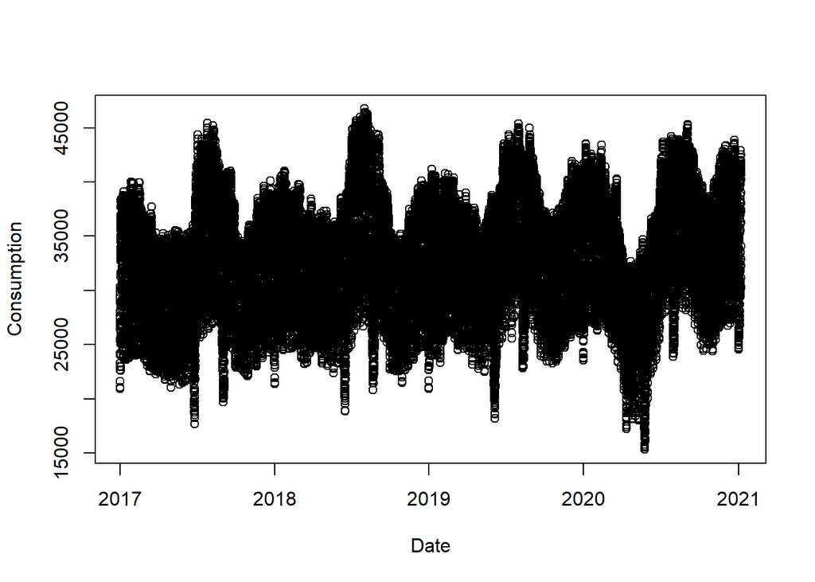

```r
df <- read.csv("C:\\Users\\Raven\\Desktop\\Ders 2020\\IE 360\\project\\bulk_consumption_with_temp.csv")
dt <- data.table(df)
dt[,Date:= as.Date(Date)]
plot(dt$Date,dt$Consumption, xlab="Date", ylab="Consumption")
```

As we can see there is a seasonality effect. We created day of week(dow), month, trend and mean temperature columns to experiment. Then created base regression model with those.

```r
dt[,Month:= month(Date)]
dt[,dow:=weekdays(Date)]
dt[,trend:= 1:.N]
dt[,mean_temp:=(T_1+T_2+T_3+T_4+T_5+T_6+T_7)/7]
fit <- glm(Consumption~-1+mean_temp+trend+dow+as.factor(Hour)+as.factor(Month), dt, family = "gaussian")
summary(fit)
```

```
##
## Call:
## glm(formula = Consumption ~ -1 + mean_temp + trend + dow + as.factor(Hour) +
##     as.factor(Month), family = "gaussian", data = dt)
##
## Deviance Residuals:
##      Min        1Q    Median        3Q       Max
## -17147.4   -1335.8     204.4    1611.0    8631.4
##
## Coefficients:
##                      Estimate Std. Error t value Pr(>|t|)
## mean_temp           1.031e+01  4.759e+00   2.166  0.03032 *
## trend               6.639e-02  1.395e-03  47.605  < 2e-16 ***
## dowCuma             3.120e+04  8.971e+01 347.776  < 2e-16 ***
## dowCumartesi        2.960e+04  8.982e+01 329.568  < 2e-16 ***
## dowÇarşamba         3.140e+04  8.950e+01 350.796  < 2e-16 ***
## dowPazar            2.645e+04  8.966e+01 295.004  < 2e-16 ***
## dowPazartesi        3.031e+04  8.958e+01 338.406  < 2e-16 ***
## dowPerşembe         3.151e+04  8.960e+01 351.669  < 2e-16 ***
## dowSalı             3.118e+04  8.950e+01 348.369  < 2e-16 ***
## as.factor(Hour)1   -1.541e+03  9.534e+01 -16.162  < 2e-16 ***
## as.factor(Hour)2   -2.604e+03  9.537e+01 -27.303  < 2e-16 ***
## as.factor(Hour)3   -3.301e+03  9.542e+01 -34.591  < 2e-16 ***
## as.factor(Hour)4   -3.613e+03  9.548e+01 -37.836  < 2e-16 ***
## as.factor(Hour)5   -3.809e+03  9.555e+01 -39.863  < 2e-16 ***
## as.factor(Hour)6   -2.989e+03  9.562e+01 -31.257  < 2e-16 ***
## as.factor(Hour)7   -1.936e+03  9.541e+01 -20.296  < 2e-16 ***
## as.factor(Hour)8    1.294e+03  9.533e+01  13.571  < 2e-16 ***
## as.factor(Hour)9    3.486e+03  9.559e+01  36.472  < 2e-16 ***
## as.factor(Hour)10   4.315e+03  9.628e+01  44.821  < 2e-16 ***
## as.factor(Hour)11   4.928e+03  9.730e+01  50.650  < 2e-16 ***
## as.factor(Hour)12   3.833e+03  9.854e+01  38.895  < 2e-16 ***
## as.factor(Hour)13   4.188e+03  9.933e+01  42.159  < 2e-16 ***
## as.factor(Hour)14   4.834e+03  9.999e+01  48.342  < 2e-16 ***
## as.factor(Hour)15   4.668e+03  1.005e+02  46.470  < 2e-16 ***
## as.factor(Hour)16   4.748e+03  9.976e+01  47.595  < 2e-16 ***
## as.factor(Hour)17   4.729e+03  9.889e+01  47.824  < 2e-16 ***
## as.factor(Hour)18   4.671e+03  9.778e+01  47.769  < 2e-16 ***
## as.factor(Hour)19   4.770e+03  9.666e+01  49.349  < 2e-16 ***
## as.factor(Hour)20   4.686e+03  9.588e+01  48.872  < 2e-16 ***
```

[output cut: 9 more lines]

```
## as.factor(Month)8   1.988e+03  1.214e+02  16.379  < 2e-16 ***
## as.factor(Month)9   2.188e+02  1.120e+02   1.953  0.05079 .
## as.factor(Month)10 -3.166e+03  9.417e+01 -33.618  < 2e-16 ***
## as.factor(Month)11 -1.626e+03  7.707e+01 -21.093  < 2e-16 ***
## as.factor(Month)12  2.171e+02  6.913e+01   3.140  0.00169 **
## ---
## Signif. codes:  0 '***' 0.001 '**' 0.01 '*' 0.05 '.' 0.1 ' ' 1
##
## (Dispersion parameter for gaussian family taken to be 6670207)
##
##     Null deviance: 3.8041e+13  on 35232  degrees of freedom
## Residual deviance: 2.3472e+11  on 35189  degrees of freedom
## AIC: 653635
##
## Number of Fisher Scoring iterations: 2
```

We need to manipulate temperature effect more, so we created daily and absolute(abs difference from total mean temp) temperature columns. Then tried model to see if there is improvement.

```r
dt[,dayly_temp:=mean(mean_temp,na.rm = T),by=list(Date)]
mt <-mean(dt$T_1+dt$T_2+dt$T_3+dt$T_4+dt$T_5+dt$T_6+dt$T_7)/7
dt[,abs_temp:=abs(dayly_temp-mt)]
fit <- glm(Consumption~-1+abs_temp+trend+dow+as.factor(Hour)+as.factor(Month), dt, family = "gaussian")
summary(fit)
```

```
##
## Call:
## glm(formula = Consumption ~ -1 + abs_temp + trend + dow + as.factor(Hour) +
##     as.factor(Month), family = "gaussian", data = dt)
##
## Deviance Residuals:
##    Min      1Q  Median      3Q     Max
## -17435   -1231     246    1572    8542
##
## Coefficients:
##                      Estimate Std. Error t value Pr(>|t|)
## abs_temp            2.240e+02  5.601e+00  39.996  < 2e-16 ***
## trend               6.760e-02  1.361e-03  49.667  < 2e-16 ***
## dowCuma             2.855e+04  1.099e+02 259.890  < 2e-16 ***
## dowCumartesi        2.699e+04  1.094e+02 246.649  < 2e-16 ***
## dowÇarşamba         2.879e+04  1.092e+02 263.687  < 2e-16 ***
## dowPazar            2.385e+04  1.092e+02 218.333  < 2e-16 ***
## dowPazartesi        2.772e+04  1.090e+02 254.276  < 2e-16 ***
## dowPerşembe         2.888e+04  1.096e+02 263.627  < 2e-16 ***
## dowSalı             2.859e+04  1.089e+02 262.470  < 2e-16 ***
## as.factor(Hour)1   -1.544e+03  9.324e+01 -16.560  < 2e-16 ***
## as.factor(Hour)2   -2.610e+03  9.324e+01 -27.995  < 2e-16 ***
## as.factor(Hour)3   -3.310e+03  9.324e+01 -35.501  < 2e-16 ***
## as.factor(Hour)4   -3.624e+03  9.324e+01 -38.871  < 2e-16 ***
## as.factor(Hour)5   -3.823e+03  9.324e+01 -41.004  < 2e-16 ***
## as.factor(Hour)6   -3.005e+03  9.324e+01 -32.228  < 2e-16 ***
## as.factor(Hour)7   -1.945e+03  9.324e+01 -20.861  < 2e-16 ***
## as.factor(Hour)8    1.296e+03  9.324e+01  13.902  < 2e-16 ***
## as.factor(Hour)9    3.502e+03  9.324e+01  37.555  < 2e-16 ***
## as.factor(Hour)10   4.345e+03  9.324e+01  46.596  < 2e-16 ***
## as.factor(Hour)11   4.971e+03  9.324e+01  53.311  < 2e-16 ***
## as.factor(Hour)12   3.887e+03  9.324e+01  41.684  < 2e-16 ***
## as.factor(Hour)13   4.248e+03  9.324e+01  45.561  < 2e-16 ***
## as.factor(Hour)14   4.899e+03  9.324e+01  52.544  < 2e-16 ***
## as.factor(Hour)15   4.737e+03  9.324e+01  50.804  < 2e-16 ***
## as.factor(Hour)16   4.812e+03  9.324e+01  51.605  < 2e-16 ***
## as.factor(Hour)17   4.786e+03  9.324e+01  51.334  < 2e-16 ***
## as.factor(Hour)18   4.718e+03  9.324e+01  50.603  < 2e-16 ***
## as.factor(Hour)19   4.805e+03  9.324e+01  51.531  < 2e-16 ***
## as.factor(Hour)20   4.708e+03  9.324e+01  50.498  < 2e-16 ***
```

[output cut: 9 more lines]

```
## as.factor(Month)8   2.601e+03  6.557e+01  39.659  < 2e-16 ***
## as.factor(Month)9   1.360e+03  6.962e+01  19.530  < 2e-16 ***
## as.factor(Month)10 -1.099e+03  8.085e+01 -13.596  < 2e-16 ***
## as.factor(Month)11  1.833e+02  7.862e+01   2.331   0.0197 *
## as.factor(Month)12  1.125e+03  6.881e+01  16.354  < 2e-16 ***
## ---
## Signif. codes:  0 '***' 0.001 '**' 0.01 '*' 0.05 '.' 0.1 ' ' 1
##
## (Dispersion parameter for gaussian family taken to be 6381016)
##
##     Null deviance: 3.8041e+13  on 35232  degrees of freedom
## Residual deviance: 2.2454e+11  on 35189  degrees of freedom
## AIC: 652074
##
## Number of Fisher Scoring iterations: 2
```

```r
fit2 <- glm(Consumption~-1+dayly_temp+trend+dow+as.factor(Hour)+as.factor(Month), dt, family = "gaussian")
summary(fit2)
```

```
##
## Call:
## glm(formula = Consumption ~ -1 + dayly_temp + trend + dow + as.factor(Hour) +
##     as.factor(Month), family = "gaussian", data = dt)
##
## Deviance Residuals:
##      Min        1Q    Median        3Q       Max
## -17204.3   -1329.0     200.2    1614.0    8576.4
##
## Coefficients:
##                      Estimate Std. Error t value Pr(>|t|)
## dayly_temp          6.280e+01  5.221e+00  12.027  < 2e-16 ***
## trend               6.533e-02  1.393e-03  46.913  < 2e-16 ***
## dowCuma             3.105e+04  9.033e+01 343.784  < 2e-16 ***
## dowCumartesi        2.946e+04  9.044e+01 325.749  < 2e-16 ***
## dowÇarşamba         3.124e+04  9.033e+01 345.806  < 2e-16 ***
## dowPazar            2.630e+04  9.034e+01 291.167  < 2e-16 ***
## dowPazartesi        3.016e+04  9.034e+01 333.840  < 2e-16 ***
## dowPerşembe         3.136e+04  9.036e+01 347.034  < 2e-16 ***
## dowSalı             3.102e+04  9.039e+01 343.130  < 2e-16 ***
## as.factor(Hour)1   -1.544e+03  9.514e+01 -16.230  < 2e-16 ***
## as.factor(Hour)2   -2.610e+03  9.514e+01 -27.436  < 2e-16 ***
## as.factor(Hour)3   -3.310e+03  9.514e+01 -34.792  < 2e-16 ***
## as.factor(Hour)4   -3.624e+03  9.514e+01 -38.095  < 2e-16 ***
## as.factor(Hour)5   -3.823e+03  9.514e+01 -40.185  < 2e-16 ***
## as.factor(Hour)6   -3.005e+03  9.514e+01 -31.584  < 2e-16 ***
## as.factor(Hour)7   -1.945e+03  9.514e+01 -20.444  < 2e-16 ***
## as.factor(Hour)8    1.296e+03  9.514e+01  13.624  < 2e-16 ***
## as.factor(Hour)9    3.502e+03  9.514e+01  36.805  < 2e-16 ***
## as.factor(Hour)10   4.345e+03  9.514e+01  45.665  < 2e-16 ***
## as.factor(Hour)11   4.971e+03  9.514e+01  52.246  < 2e-16 ***
## as.factor(Hour)12   3.887e+03  9.514e+01  40.852  < 2e-16 ***
## as.factor(Hour)13   4.248e+03  9.514e+01  44.652  < 2e-16 ***
## as.factor(Hour)14   4.899e+03  9.514e+01  51.495  < 2e-16 ***
## as.factor(Hour)15   4.737e+03  9.514e+01  49.789  < 2e-16 ***
## as.factor(Hour)16   4.812e+03  9.514e+01  50.575  < 2e-16 ***
## as.factor(Hour)17   4.786e+03  9.514e+01  50.309  < 2e-16 ***
## as.factor(Hour)18   4.718e+03  9.514e+01  49.593  < 2e-16 ***
## as.factor(Hour)19   4.805e+03  9.514e+01  50.502  < 2e-16 ***
## as.factor(Hour)20   4.708e+03  9.514e+01  49.490  < 2e-16 ***
```

[output cut: 9 more lines]

```
## as.factor(Month)8   8.665e+02  1.297e+02   6.682 2.39e-11 ***
## as.factor(Month)9  -7.717e+02  1.190e+02  -6.482 9.15e-11 ***
## as.factor(Month)10 -3.902e+03  9.878e+01 -39.498  < 2e-16 ***
## as.factor(Month)11 -2.042e+03  7.882e+01 -25.912  < 2e-16 ***
## as.factor(Month)12  1.865e+01  6.948e+01   0.268    0.788
## ---
## Signif. codes:  0 '***' 0.001 '**' 0.01 '*' 0.05 '.' 0.1 ' ' 1
##
## (Dispersion parameter for gaussian family taken to be 6643786)
##
##     Null deviance: 3.8041e+13  on 35232  degrees of freedom
## Residual deviance: 2.3379e+11  on 35189  degrees of freedom
## AIC: 653495
##
## Number of Fisher Scoring iterations: 2
```

Abs temp is working better. Then we plot the residuals to see problems of model.

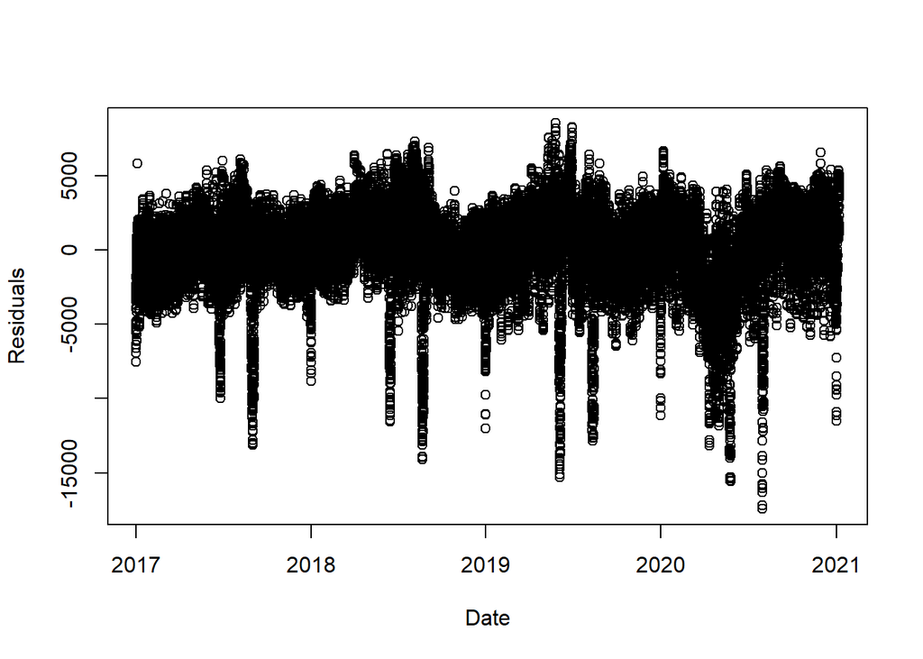

```r
plot(dt$Date, fit$residuals , xlab="Date", ylab="Residuals")
```

There is special day effect creating outliers so we tried to get rid of them by creating a dummy variable names is.outlier. Is.outlier is one if residual of that day is lesser than %2 of data, zero otherwise.

```r
dt[,is.outlier:=0]
dt[,residuals:=residuals(fit)]
quan2=quantile(dt$residuals,0.02, na.rm = T)
dt[residuals<quan2,is.outlier:=1]
fit_new <- glm(Consumption~-1+abs_temp+trend+dow+is.outlier+as.factor(Hour)+as.factor(Month), dt, family = "gaussian")
summary(fit_new)
```

```
##
## Call:
## glm(formula = Consumption ~ -1 + abs_temp + trend + dow + is.outlier +
##     as.factor(Hour) + as.factor(Month), family = "gaussian",
##     data = dt)
##
## Deviance Residuals:
##     Min       1Q   Median       3Q      Max
## -7775.1  -1257.6    143.7   1391.2   8260.1
##
## Coefficients:
##                      Estimate Std. Error  t value Pr(>|t|)
## abs_temp            2.323e+02  4.680e+00   49.645   <2e-16 ***
## trend               7.432e-02  1.138e-03   65.290   <2e-16 ***
## dowCuma             2.842e+04  9.180e+01  309.654   <2e-16 ***
## dowCumartesi        2.686e+04  9.144e+01  293.703   <2e-16 ***
## dowÇarşamba         2.857e+04  9.123e+01  313.185   <2e-16 ***
## dowPazar            2.364e+04  9.127e+01  259.010   <2e-16 ***
## dowPazartesi        2.756e+04  9.109e+01  302.593   <2e-16 ***
## dowPerşembe         2.868e+04  9.154e+01  313.326   <2e-16 ***
## dowSalı             2.848e+04  9.101e+01  312.931   <2e-16 ***
## is.outlier         -1.009e+04  8.178e+01 -123.411   <2e-16 ***
## as.factor(Hour)1   -1.565e+03  7.789e+01  -20.087   <2e-16 ***
## as.factor(Hour)2   -2.631e+03  7.789e+01  -33.775   <2e-16 ***
## as.factor(Hour)3   -3.338e+03  7.789e+01  -42.847   <2e-16 ***
## as.factor(Hour)4   -3.652e+03  7.789e+01  -46.882   <2e-16 ***
## as.factor(Hour)5   -3.816e+03  7.789e+01  -48.993   <2e-16 ***
## as.factor(Hour)6   -2.950e+03  7.790e+01  -37.871   <2e-16 ***
## as.factor(Hour)7   -1.835e+03  7.790e+01  -23.557   <2e-16 ***
## as.factor(Hour)8    1.537e+03  7.792e+01   19.722   <2e-16 ***
## as.factor(Hour)9    3.818e+03  7.794e+01   48.985   <2e-16 ***
## as.factor(Hour)10   4.668e+03  7.794e+01   59.888   <2e-16 ***
## as.factor(Hour)11   5.280e+03  7.793e+01   67.748   <2e-16 ***
## as.factor(Hour)12   4.113e+03  7.792e+01   52.793   <2e-16 ***
## as.factor(Hour)13   4.475e+03  7.792e+01   57.432   <2e-16 ***
## as.factor(Hour)14   5.140e+03  7.792e+01   65.962   <2e-16 ***
## as.factor(Hour)15   4.977e+03  7.792e+01   63.879   <2e-16 ***
## as.factor(Hour)16   5.011e+03  7.791e+01   64.316   <2e-16 ***
## as.factor(Hour)17   4.951e+03  7.791e+01   63.553   <2e-16 ***
## as.factor(Hour)18   4.849e+03  7.790e+01   62.241   <2e-16 ***
```

[output cut: 11 more lines]

```
## as.factor(Month)8   3.147e+03  5.496e+01   57.252   <2e-16 ***
## as.factor(Month)9   1.426e+03  5.816e+01   24.510   <2e-16 ***
## as.factor(Month)10 -1.212e+03  6.755e+01  -17.947   <2e-16 ***
## as.factor(Month)11  5.867e+01  6.569e+01    0.893    0.372
## as.factor(Month)12  9.737e+02  5.750e+01   16.935   <2e-16 ***
## ---
## Signif. codes:  0 '***' 0.001 '**' 0.01 '*' 0.05 '.' 0.1 ' ' 1
##
## (Dispersion parameter for gaussian family taken to be 4453573)
##
##     Null deviance: 3.8041e+13  on 35232  degrees of freedom
## Residual deviance: 1.5671e+11  on 35188  degrees of freedom
## AIC: 639404
##
## Number of Fisher Scoring iterations: 2
```

Our model improved, we check stationarity with new residuals.

```r
dt[,residuals_new:=fit_new$residuals]
unt_test=ur.kpss(dt$residuals_new)
summary(unt_test)
```

```
##
## #######################
## # KPSS Unit Root Test #
## #######################
##
## Test is of type: mu with 17 lags.
##
## Value of test-statistic is: 2.6223
##
## Critical value for a significance level of:
##                 10pct  5pct 2.5pct  1pct
## critical values 0.347 0.463  0.574 0.739
```

Not stationary so we create a differ column with lag 24 and try kpss test again.

```r
dt[,differ:=residuals_new-shift(residuals_new,24)]
unt_test2=ur.kpss(dt$differ)
summary(unt_test2)
```

```
##
## #######################
## # KPSS Unit Root Test #
## #######################
##
## Test is of type: mu with 17 lags.
##
## Value of test-statistic is: 0.0049
##
## Critical value for a significance level of:
##                 10pct  5pct 2.5pct  1pct
## critical values 0.347 0.463  0.574 0.739
```

Differ is stationary enough, we start to ARIMA.

```r
arima_fitted=auto.arima(dt$differ,seasonal=F,trace=T)
```

```
##
##  Fitting models using approximations to speed things up...
##
##  ARIMA(2,0,2) with non-zero mean : 593608.5
##  ARIMA(0,0,0) with non-zero mean : 633246.7
##  ARIMA(1,0,0) with non-zero mean : 594669.3
##  ARIMA(0,0,1) with non-zero mean : 609659.9
##  ARIMA(0,0,0) with zero mean     : 633244.9
##  ARIMA(1,0,2) with non-zero mean : 593989.2
##  ARIMA(2,0,1) with non-zero mean : 593608.7
##  ARIMA(3,0,2) with non-zero mean : Inf
##  ARIMA(2,0,3) with non-zero mean : 593601.2
##  ARIMA(1,0,3) with non-zero mean : 593893.3
##  ARIMA(3,0,3) with non-zero mean : Inf
##  ARIMA(2,0,4) with non-zero mean : Inf
##  ARIMA(1,0,4) with non-zero mean : 593894
##  ARIMA(3,0,4) with non-zero mean : Inf
##  ARIMA(2,0,3) with zero mean     : 593897.1
##
##  Now re-fitting the best model(s) without approximations...
##
##  ARIMA(2,0,3) with non-zero mean : 593604
##
##  Best model: ARIMA(2,0,3) with non-zero mean
```

```r
summary(arima_fitted)
```

```
## Series: dt$differ
## ARIMA(2,0,3) with non-zero mean
##
## Coefficients:
##          ar1      ar2      ma1     ma2     ma3     mean
##       1.5747  -0.6696  -0.6800  0.0070  0.0244   4.6959
## s.e.  0.0126   0.0099   0.0137  0.0068  0.0080  21.8766
##
## sigma^2 estimated as 1229083:  log likelihood=-296795
## AIC=593604   AICc=593604   BIC=593663.2
##
## Training set error measures:
##                      ME     RMSE     MAE     MPE     MAPE    MASE         ACF1
## Training set -0.0843218 1108.546 496.214 48.7451 305.5161 1.00686 0.0007546866
```

We can make forecast by forecasting 48 ahead ARIMA, creating 48 lag residuals by repeating 24 lag res 2 times ,getting forecast from regression model (fit_new) then adding them all.

# 4 Model2

## 4.1 The Data

```python
import pandas as pd
import numpy as np
import json
import datetime
import requests

# Below is a sample script for your submissions.
# We advise you to play around with the code and read it carefully.
# Feel free to grab the utility functions below and experiment with them yourself.
# We want to remind you that you can submit more than once, and we will use the latest one.
# IMPORTANT: Below, you need to fill your `predict` function for your predictions
# and add your username & password in the space below.
# Set submit_now to false if you are experimenting and just want to see the result of your predictions.
# Set to True if you actually want to submit.

URL = 'http://46.101.124.77'

USERNAME = "Group14"
PASSWORD = "wio6Z5O4tW9vH54P"
submit_now = False  # Set this to True if you want to submit your predictions.


def predict(data: pd.DataFrame):
  ### YOUR CODE GOES HERE
  """
    Students are expected to fill this method.
    :param data: Data that was obtained from the API.
    :return: A list of floats with length 24
    """

  predictions = [i for i in range(24)]
  ### YOUR CODE ENDS HERE
  print(predictions)  # Should be a list of forecasts
  # i.e. [0, 1, 2, 3, ...., 23]
  return predictions


### CODE BY THE TEACHING STAFF BEGINS HERE - YOU DO NOT NEED TO CHANGE###


def get_token(username, password):
  body = {"username": username, "password": password}
  r = requests.post(f'{URL}/token/', data=body)
  r = r.json()
  token = r["key"]
  return token


def get_data(token, start_date='2020-03-20'):
  # Date format : YEAR-MONTH-DAY
  header = {'Authorization': f'Token {token}'}
  r = requests.get(f'{URL}/dataset/',
                   params={'start_date': start_date},
                   headers=header)
  r = r.json()
  data = pd.DataFrame.from_dict(r)
  data["event_date"] = pd.to_datetime(data["event_date"])
  data = data.sort_values(by=["event_date"])
  return data


def check_format(predictions):
  assert isinstance(predictions, list)
  for i, pred in enumerate(predictions):
    try:
      predictions[i] = float(pred)
    except:
      error_str = f"Your prediction for Hour = {i} is not a numerical value. Please cast it to either native Python int/floats, or np.number subtype before submission."
      raise ValueError(error_str)


def send_submission(predictions: dict, token: str, submit_now: bool):
  check_format(predictions)
  submission = predictions
  print(f"Your submission will be : {submission}")

  if not submit_now:
    print("You did not submit.")
    return

  submission_body = {"submission": json.dumps(submission)}
  header = {'Authorization': f'Token {token}'}
  r = requests.post(f'{URL}/submission/', data=submission_body, headers=header)

  if r.status_code == 201:
    print(
        "Successfully submitted. Below you can see the details of your submission"
    )

  else:
    print(
        "Could not submit. Please check the error message below, contact the assistant if needed."
    )

  r = r.json()
  print(r)


if __name__ == "__main__":
  ### YOUR CODE GOES HERE
  username = "Group14"
  password = "wio6Z5O4tW9vH54P"
  ### YOUR CODE ENDS HERE
  token = get_token(username, password)
  data = get_data(token)
  ###prediction = predict(data)
  ###send_submission(prediction, token, submit_now)

data.head()
```

```
##     event_date  event_hour  consumption   t_1  ...    t_4    t_5    t_6    t_7
## 959 2021-01-08          13     39859.36  9.05  ...  11.33  13.68  10.31  14.84
## 936 2021-01-08          14     40986.25  9.16  ...  12.26  14.45  10.79  15.41
## 937 2021-01-08          12     40496.14  8.75  ...  10.03  13.02   9.55  14.36
## 938 2021-01-08          11     42005.09  8.08  ...   8.62  11.13   8.63  13.93
## 939 2021-01-08          10     41592.27  7.08  ...   6.98   8.70   7.32  13.17
##
## [5 rows x 10 columns]
```

## 4.2 Date Features

```python
data['Date'] = pd.to_datetime(data['event_date'])
#data['Date'] = data['Date'].dt.strftime('%d.%m.%Y')
data['Date'] = data['Date'].dt.strftime('%Y.%m.%d')
data['year'] = pd.DatetimeIndex(data['Date']).year
data['month'] = pd.DatetimeIndex(data['Date']).month
data['day'] = pd.DatetimeIndex(data['Date']).day
data['dayofyear'] = pd.DatetimeIndex(data['Date']).dayofyear
data['weekofyear'] = pd.DatetimeIndex(data['Date']).weekofyear
data['weekday'] = pd.DatetimeIndex(data['Date']).weekday
data['quarter'] = pd.DatetimeIndex(data['Date']).quarter
data['is_month_start'] = pd.DatetimeIndex(data['Date']).is_month_start
data['is_month_end'] = pd.DatetimeIndex(data['Date']).is_month_end
print(data.info())
```

```
## <class 'pandas.core.frame.DataFrame'>
## Int64Index: 960 entries, 959 to 0
## Data columns (total 20 columns):
##  #   Column          Non-Null Count  Dtype
## ---  ------          --------------  -----
##  0   event_date      960 non-null    datetime64[ns]
##  1   event_hour      960 non-null    int64
##  2   consumption     960 non-null    float64
##  3   t_1             960 non-null    float64
##  4   t_2             960 non-null    float64
##  5   t_3             960 non-null    float64
##  6   t_4             960 non-null    float64
##  7   t_5             960 non-null    float64
##  8   t_6             960 non-null    float64
##  9   t_7             960 non-null    float64
##  10  Date            960 non-null    object
##  11  year            960 non-null    int64
##  12  month           960 non-null    int64
##  13  day             960 non-null    int64
##  14  dayofyear       960 non-null    int64
##  15  weekofyear      960 non-null    int64
##  16  weekday         960 non-null    int64
##  17  quarter         960 non-null    int64
##  18  is_month_start  960 non-null    bool
##  19  is_month_end    960 non-null    bool
## dtypes: bool(2), datetime64[ns](1), float64(8), int64(8), object(1)
## memory usage: 144.4+ KB
## None
```

Sometimes classical time series algorithms won’t suffice for making powerful predictions. In such cases, it’s sensible to convert the time series data to a machine learning algorithm by creating features from the time variable. The code below uses the pd.DatetimeIndex() function to create time features like year, day of the year, quarter, month, day, weekdays, etc.

## 4.3 Dummy Encoding

Some of the variables in the dataset, such as year or quarter, need to be treated as categorical variables. So, we will convert these variables to numeric variables that can be used as factors using a technique called dummy encoding. In this technique, the features are encoded so there is no duplication of the information. This is achieved by passing in the argument drop_first=True to the .get_dummies() function, as done in the code below. The last line prints the information about the data.

```python
data = pd.get_dummies(data, columns=['year'], drop_first=True, prefix='year')

data = pd.get_dummies(data, columns=['month'], drop_first=True, prefix='month')

data = pd.get_dummies(data, columns=['weekday'], drop_first=True, prefix='wday')
data = pd.get_dummies(data, columns=['quarter'], drop_first=True, prefix='qrtr')

data = pd.get_dummies(data, columns=['is_month_start'], drop_first=True, prefix='m_start')

data = pd.get_dummies(data, columns=['is_month_end'], drop_first=True, prefix='m_end')

data.info()
```

```
## <class 'pandas.core.frame.DataFrame'>
## Int64Index: 960 entries, 959 to 0
## Data columns (total 23 columns):
##  #   Column        Non-Null Count  Dtype
## ---  ------        --------------  -----
##  0   event_date    960 non-null    datetime64[ns]
##  1   event_hour    960 non-null    int64
##  2   consumption   960 non-null    float64
##  3   t_1           960 non-null    float64
##  4   t_2           960 non-null    float64
##  5   t_3           960 non-null    float64
##  6   t_4           960 non-null    float64
##  7   t_5           960 non-null    float64
##  8   t_6           960 non-null    float64
##  9   t_7           960 non-null    float64
##  10  Date          960 non-null    object
##  11  day           960 non-null    int64
##  12  dayofyear     960 non-null    int64
##  13  weekofyear    960 non-null    int64
##  14  month_2       960 non-null    uint8
##  15  wday_1        960 non-null    uint8
##  16  wday_2        960 non-null    uint8
##  17  wday_3        960 non-null    uint8
##  18  wday_4        960 non-null    uint8
##  19  wday_5        960 non-null    uint8
##  20  wday_6        960 non-null    uint8
##  21  m_start_True  960 non-null    uint8
##  22  m_end_True    960 non-null    uint8
## dtypes: datetime64[ns](1), float64(8), int64(4), object(1), uint8(9)
## memory usage: 120.9+ KB
```

## 4.4 Data Partitioning

With the data prepared, we are ready to move to machine learning in the subsequent sections. However, before moving to predictive modeling techniques, it’s important to divide the data into training and test sets.

```python
data=data.sort_values(by=['Date', 'event_hour'])
X=data[['event_hour', 't_1', 't_2',
       't_3', 't_4', 't_5', 't_6', 't_7', 'day', 'dayofyear',
       'weekofyear', 'wday_1', 'wday_2', 'wday_3', 'wday_4', 'wday_5',
       'wday_6', 'wday_1', 'wday_2', 'wday_3', 'wday_4', 'wday_5', 'wday_6']]
y=data[['consumption']]
#data.shape
#y.iloc[791]
X_train=X.head(791)
X_test=X.tail(48)
y_train=y.head(791)
y_test=y.tail(48)
X_train = X_train.values
y_train = y_train.values
#print(X_train.shape)
#print(y_train.shape)
X_test = X_test.values
y_test = y_test.values

#print(X_test.shape)
#print(y_test.shape)
```

## 4.5 Random Forest

Decision Trees are useful, but they often tend to overfit the training data, leading to high variances in the test data. Random Forest algorithms overcome this shortcoming by reducing the variance of the decision trees. They are called a Forest because they are the collection, or ensemble, of several decision trees. One major difference between a Decision Tree and a Random Forest model is how the splits happen. In a Random Forest, instead of trying splits on all the features, a sample of features is selected for each split, thereby reducing the variance of the model.

In scikit-learn, the RandomForestRegressor class is used for building regression trees. The first line of code below instantiates the Random Forest Regression model with an n_estimators value of 1000. The argument n_estimators indicates the number of trees in the forest. The second line fits the model to the training data.

```python
from sklearn import model_selection
from sklearn.tree import DecisionTreeRegressor
from sklearn.ensemble import RandomForestRegressor
from sklearn.metrics import r2_score
from sklearn.metrics import mean_squared_error
from math import sqrt

#RF model
model_rf = RandomForestRegressor(n_estimators=1000, oob_score=True, random_state=100)
model_rf.fit(X_train, y_train)
```

```
## RandomForestRegressor(n_estimators=1000, oob_score=True, random_state=100)
##
```

```python
pred_train_rf= model_rf.predict(X_train)
print(np.sqrt(mean_squared_error(y_train,pred_train_rf)))
```

```
## 228.98371605451112
```

```python
print(r2_score(y_train, pred_train_rf))
```

```
## 0.9979941382127444
```

```python
pred_test_rf = model_rf.predict(X_test)
print(pred_test_rf)
```

```
## [32831.72233 31259.74262 29914.06825 29428.53153 29577.1424  29580.71977
##  29796.08364 31642.5942  37516.93015 42042.20491 44474.18376 44607.15327
##  44538.9464  44553.40556 44689.94124 44676.04624 44178.77615 43409.67648
##  42808.78935 41883.39576 39462.96668 38693.23769 37860.63797 36926.50695
##  33500.88503 31748.19441 30370.46666 29947.61552 29956.26261 29894.14263
##  30160.37306 32051.98026 37791.29779 43248.6522  45759.89543 46033.41504
##  45937.54045 45566.31933 45552.71964 45317.21075 44688.43591 43993.29091
##  43387.75088 42542.74048 40312.71641 39502.61209 38719.59534 37689.80639]
```

According to mean squared error the model has a good accuracy. According to R squared score the model explaining enough variance.

# 5 Results

We have used those two models to predict hourly consumption for 29th, 30th, 31th of January and calculated Weighted Mean Absolute Percentage Errors. Model 1 had 0.335422493, 0.190382615, 0.234456921 WPAPE respectively. Model 2 had 0.224362132, 0.105402221, 0.125799237 WPAPE respectively. So, decided to submit Model 2 predictions for the rest of the project.

# 6 Conclusion

We created two models and they performed according to our expectations. However, there is always a room for improvements. For example, investigating outliers/finding and including special occasions such as holidays would improve the overall results. Also, we used Random Forest ML algorithm without having a solid theoretical background. If we would have a better understanding of this algorithm we would tune the parameters to obtain better results.

# 7 References

• [ARIMA forecasting of primary energy demand by fuel in Turkey](https://www.researchgate.net/publication/4947915_ARIMA_forecasting_of_primary_energy_demand_by_fuel_in_Turkey)

• [Comparison of ARIMA and Random Forest time series models for prediction of avian influenza H5N1 outbreaks](https://bmcbioinformatics.biomedcentral.com/articles/10.1186/1471-2105-15-276)

• [Forecasting electricity consumption: A comparison of regression analysis, neural networks and least squares support vector machines](https://www.researchgate.net/publication/270006584_Forecasting_electricity_consumption_A_comparison_of_regression_analysis_neural_networks_and_least_squares_support_vector_machines)

• [Electrical Energy Consumption Estimation by Genetic Algorithm and Analysis of Variance](https://www.researchgate.net/publication/265477677_Electrical_Energy_Consumption_Estimation_by_Genetic_Algorithm_and_Analysis_of_Variance)